# Relationship between Number of Fires and Acres Burned Across USA

## Source

Main data sources were from https://www.iii.org/table-archive/23284 and https://www.nifc.gov/fire-information/statistics/wildfires. Both the insurance information institute and national interagency fire center are trustable sources and have a vested interest in preventing wildfires and wildfire damage.

## Datasets

Using the sources above two primary datasets were created.TotalWildfiresAndAcres, which compiles # of fires and # of acres burned from 1983 - 2022 and USA state wildfires which stratifies these metrics by individual states, from 2010-2021.It should be noted that the year 2012 is not present in the USA state wildfires dataset because it was not present in the iii archive.

We can begin our analysis by examining the relationship between number of fires and number of acres:

```r
library(readxl)
library(ggplot2)
TotalWildfiresAndAcres <- read_excel(path = "C:/ram/pro/TAMU/2023DataCompetition/TotalWildfiresAndAcres.xlsx")
USAStateWildfires <- read_excel(path = "C:/ram/pro/TAMU/2023DataCompetition/USAStateWildfires.xlsx")
summary(TotalWildfiresAndAcres)
```

```
##       Year          Fires           Acres
##  Min.   :1983   Min.   :18229   Min.   : 1148409
##  1st Qu.:1993   1st Qu.:63550   1st Qu.: 2886350
##  Median :2002   Median :71400   Median : 4836827
##  Mean   :2002   Mean   :69980   Mean   : 5330347
##  3rd Qu.:2012   3rd Qu.:81341   3rd Qu.: 7707357
##  Max.   :2022   Max.   :96385   Max.   :10125149
```

```r
TotalWildfiresAndAcres
```

```
## # A tibble: 40 × 3
##     Year Fires    Acres
##    <dbl> <dbl>    <dbl>
##  1  2022 68988  7577183
##  2  2021 58985  7125643
##  3  2020 58950 10122336
##  4  2019 50477  4664364
##  5  2018 58083  8767492
##  6  2017 71499 10026086
##  7  2016 67743  5509995
##  8  2015 68151 10125149
##  9  2014 63312  3595613
## 10  2013 47579  4319546
## # … with 30 more rows
```

```r
dim(TotalWildfiresAndAcres)
```

```
## [1] 40  3
```

```r
summary(USAStateWildfires)
```

```
##     State           Number of Fires    Number of Acres Burned      Year
##  Length:558         Length:558         Length:558             Min.   :2010
##  Class :character   Class :character   Class :character       1st Qu.:2013
##  Mode  :character   Mode  :character   Mode  :character       Median :2016
##                                                               Mean   :2016
##                                                               3rd Qu.:2019
##                                                               Max.   :2021
```

```r
USAStateWildfires
```

```
## # A tibble: 558 × 4
##    State       `Number of Fires` `Number of Acres Burned`  Year
##    <chr>       <chr>             <chr>                    <dbl>
##  1 Alabama     2093              40527                     2014
##  2 Alaska      384               233561                    2014
##  3 Arizona     1543              205199                    2014
##  4 Arkansas    1302              20164                     2014
##  5 California  7865              555044                    2014
##  6 Colorado    830               24949                     2014
##  7 Connecticut 28                69                        2014
##  8 Delaware    0                 0                         2014
##  9 Florida     2436              101599                    2014
## 10 Georgia     3562              19199                     2014
## # … with 548 more rows
```

```r
dim(USAStateWildfires)
```

```
## [1] 558   4
```

## Starting Plots

From this data we can start with some plots:

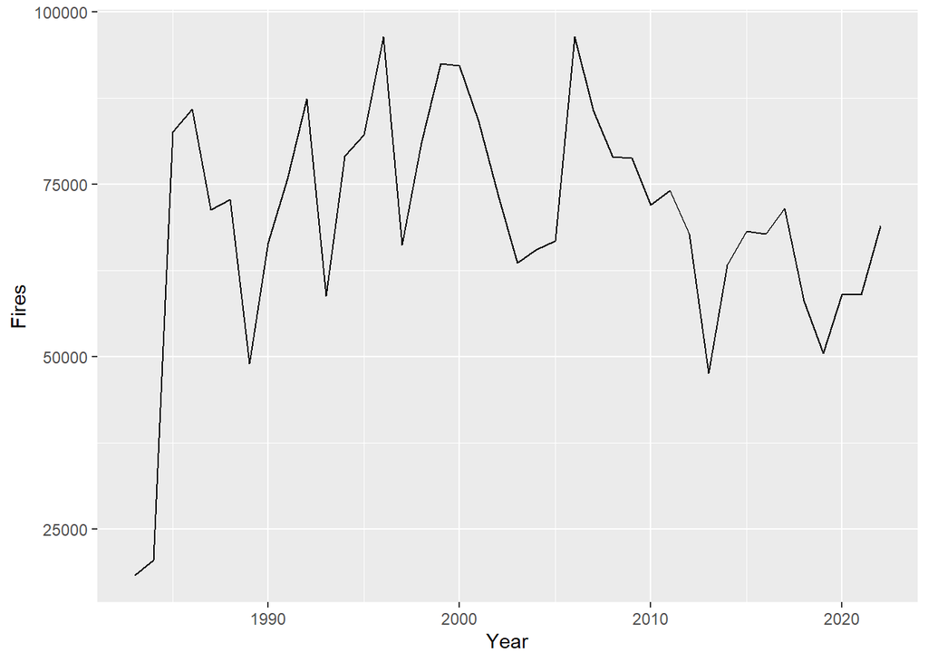

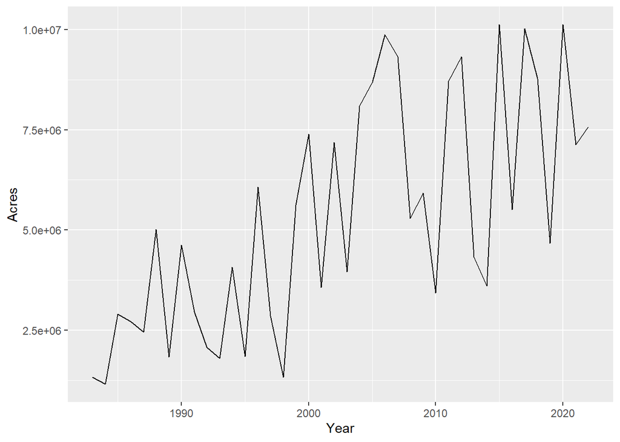

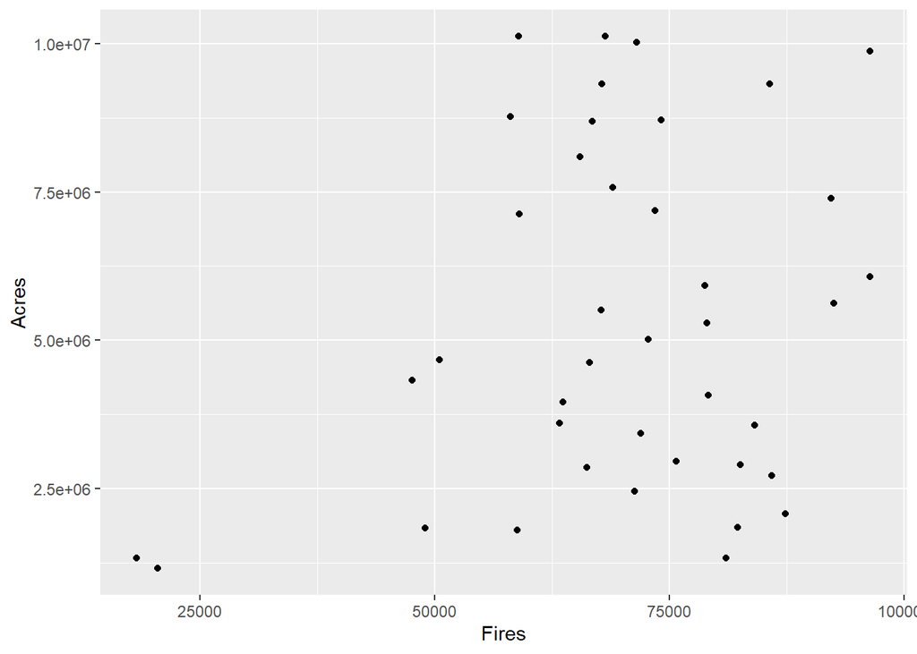

From the plots we can see that in general over time more acres are being burned. The relationship between fires and years however is less obvious. We can also see that the scatterplot between fires and acres yields some interesting discoveries. In general low fire years lead to low acre burns however high fire years do not necessarily correlate to high acre burns. Fitting trend lines to these plots will help us analyze further and forecast future numbers.

## Forecasting Plots

Tableau dashboards will be used for added interactivity, and as well for the impressive analytics tools and animation capability built in to the platform.

[figure not shown]

The Visualization above has a filter so you can examine a group of years closer. It also shows clouds of forecasts for fires and acres in the next 2-5 years. Use mouse to hover to see numbers and use mouse to adjust slider. Trend lines and forecasts will change based on what years are chosen in the slider.

Now that we have a better idea of fire and acre numbers as a whole, let us see how we can granularize this data by state. States can be broken into fire regions based on, https://www.worldatlas.com/articles/the-officially-recognized-four-regions-and-nine-divisions-of-the-united-states.html

## USA State Fire Animation

First let us see an animation of Number of Fires Across the Years over different states.

[figure not shown]

From this animation we can draw some interesting conclusions. Namely we see that there are quite a considerable amount of fires in Texas and in southeastern states. We also see that California has a high number of fires, although this is not consistent throughout the years. For the viz above a filter is available to focus on a specific state, one can pan around the map with shift+Left click. It is also possible to play the animation forward and backward with the bar at the top-middle.YOu can also hover over a state to see the exact number of fires plus state name. A user can scroll with the mouse wheel to zoom in and out.

With this initial animation it would be useful to see which regions require the most focus in term of forest fire help. A first glance tells us that the west and south of the country are problem areas. We can look at a racing bar chart to examine this criteria and confirm our hypothesis.

## US Fires Bar Race

[figure not shown]

Focusing on the top 10 states/bars we can very clearly see that the majority of these high-fire states belong to the south and west regions, thus confirming our hypothesis.

With this in mind, it is important to now analyze how many acres were burned through each state. This is important because this metric is a showcase of fire-fighting effectiveness of a state. If a state has a large number of fires but a low number of acres burned this can be attributed to an effective fire-fighting force and response system.

## US Acres Burned Animation

[figure not shown]

From this animation, we can see that the size of the state can have an influence on acres burned.For example, Alaska is a huge state and as a result is often at the top in terms of acres burned. Whether this is because Alaska is simply not prepared for forest fires, or has no need to fight them because of the harsh landscape and low population density of the state is a different story. We can also see that number of fires doesn’t always mean more acres burned, as a number of states with high amount of fires were often low on the acres burned scale.

Having now seen the what constitutes fire amounts and acres burned. Is there a way we can predict where a state will end up relative to past fire season performance? Hopefully the next visualization will provide a unique insight into averages of these metrics and what can be expected.

## FiresVSAcres Bubble Animation

From our data we can find the average number of fires and the average number of acres burned over the roughly 10 year rime span. Plotting these averages over the years and comparing with state fire metrics yields interesting results.

[figure not shown]

The purple lines are the average lines for acres burned and number of fires.It is important to note that the scales on each axis are different. Fires go up to 10,000+ while acres goes up to 6 million+. The overall average lines did change throughout the years however it was evident that the intersection of the lines was relatively consistent landing between 1000 - 1500 fires and 60,000 to 205,000 acres burned. These guidelines give us a good grid guideline that can be used to allocate resources better.

An example of this is as follows:

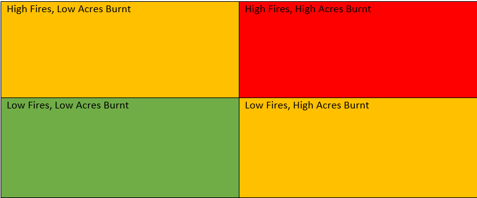

Here Red would be high fire risk, yellow moderate, and green low fire risk. Using this guideline we can see that many states from the bubble animation are consistently in the low risk range, while a select few even being high risk. Using this grid as a guideline could serve as a basis for a warning system. Of course early tracking off fires and plotting of data would be necessary, but if we can track these two metrics for a state we can plot the states relative risk on the grid and provide advance warning to citizens of the fire risk in their area, as well as aid to governments to help mitigate fire damages.